# Risk Factor Analysis

## Outcome Variable

**Outcome Variable:** stunted

## Predictor Variables

**Intervention Variable:** predfeed3

**Adjustment Set:**

- arm
- sex
- month
- brthmon
- W_mage
- meducyrs
- feducyrs
- hhwealth_quart
- hfoodsec
- W_mhtcm
- W_mwtkg
- W_mbmi
- vagbrth
- W_gagebrth
- W_birthwt
- W_birthlen
- W_nrooms
- W_nchldlt5
- W_parity
- impfloor
- impsan
- safeh20
- delta_W_mage
- delta_meducyrs
- delta_feducyrs
- delta_hhwealth_quart
- delta_hfoodsec
- delta_W_mhtcm
- delta_W_mwtkg
- delta_W_mbmi
- delta_vagbrth
- delta_W_gagebrth
- delta_W_birthwt
- delta_W_birthlen
- delta_W_nrooms
- delta_W_nchldlt5
- delta_W_parity
- delta_impfloor
- delta_impsan
- delta_safeh20

## Stratifying Variables

The analysis was stratified on these variable(s):

- agecat
- studyid
- country

## Data Summary

| agecat | studyid | country | predfeed3 | stunted | n_cell | n |
| --- | --- | --- | --- | --- | --- | --- |
| Birth | EE | PAKISTAN | 1 | 0 | 20 | 35 |
| Birth | EE | PAKISTAN | 1 | 1 | 15 | 35 |
| Birth | EE | PAKISTAN | 0 | 0 | 0 | 35 |
| Birth | EE | PAKISTAN | 0 | 1 | 0 | 35 |
| Birth | GMS-Nepal | NEPAL | 1 | 0 | 317 | 458 |
| Birth | GMS-Nepal | NEPAL | 1 | 1 | 63 | 458 |
| Birth | GMS-Nepal | NEPAL | 0 | 0 | 63 | 458 |
| Birth | GMS-Nepal | NEPAL | 0 | 1 | 15 | 458 |
| Birth | JiVitA-3 | BANGLADESH | 1 | 0 | 8077 | 13276 |
| Birth | JiVitA-3 | BANGLADESH | 1 | 1 | 3940 | 13276 |
| Birth | JiVitA-3 | BANGLADESH | 0 | 0 | 817 | 13276 |
| Birth | JiVitA-3 | BANGLADESH | 0 | 1 | 442 | 13276 |
| Birth | JiVitA-4 | BANGLADESH | 1 | 0 | 71 | 116 |
| Birth | JiVitA-4 | BANGLADESH | 1 | 1 | 34 | 116 |
| Birth | JiVitA-4 | BANGLADESH | 0 | 0 | 7 | 116 |
| Birth | JiVitA-4 | BANGLADESH | 0 | 1 | 4 | 116 |
| Birth | MAL-ED | BANGLADESH | 1 | 0 | 141 | 215 |
| Birth | MAL-ED | BANGLADESH | 1 | 1 | 35 | 215 |
| Birth | MAL-ED | BANGLADESH | 0 | 0 | 34 | 215 |
| Birth | MAL-ED | BANGLADESH | 0 | 1 | 5 | 215 |
| Birth | MAL-ED | BRAZIL | 1 | 0 | 21 | 57 |
| Birth | MAL-ED | BRAZIL | 1 | 1 | 3 | 57 |
| Birth | MAL-ED | BRAZIL | 0 | 0 | 28 | 57 |
| Birth | MAL-ED | BRAZIL | 0 | 1 | 5 | 57 |
| Birth | MAL-ED | INDIA | 1 | 0 | 21 | 41 |
| Birth | MAL-ED | INDIA | 1 | 1 | 8 | 41 |
| Birth | MAL-ED | INDIA | 0 | 0 | 12 | 41 |
| Birth | MAL-ED | INDIA | 0 | 1 | 0 | 41 |
| Birth | MAL-ED | NEPAL | 1 | 0 | 13 | 26 |
| Birth | MAL-ED | NEPAL | 1 | 1 | 1 | 26 |

[output cut: 102 more lines]

The following strata were considered:

- agecat: 24 months, studyid: EE, country: PAKISTAN
- agecat: 24 months, studyid: GMS-Nepal, country: NEPAL
- agecat: 24 months, studyid: JiVitA-3, country: BANGLADESH
- agecat: 24 months, studyid: JiVitA-4, country: BANGLADESH
- agecat: 24 months, studyid: MAL-ED, country: BANGLADESH
- agecat: 24 months, studyid: MAL-ED, country: BRAZIL
- agecat: 24 months, studyid: MAL-ED, country: INDIA
- agecat: 24 months, studyid: MAL-ED, country: NEPAL
- agecat: 24 months, studyid: MAL-ED, country: PERU
- agecat: 24 months, studyid: MAL-ED, country: SOUTH AFRICA
- agecat: 24 months, studyid: MAL-ED, country: TANZANIA, UNITED REPUBLIC OF
- agecat: 6 months, studyid: EE, country: PAKISTAN
- agecat: 6 months, studyid: GMS-Nepal, country: NEPAL
- agecat: 6 months, studyid: JiVitA-3, country: BANGLADESH
- agecat: 6 months, studyid: JiVitA-4, country: BANGLADESH
- agecat: 6 months, studyid: MAL-ED, country: BANGLADESH
- agecat: 6 months, studyid: MAL-ED, country: BRAZIL
- agecat: 6 months, studyid: MAL-ED, country: INDIA
- agecat: 6 months, studyid: MAL-ED, country: NEPAL
- agecat: 6 months, studyid: MAL-ED, country: PERU
- agecat: 6 months, studyid: MAL-ED, country: SOUTH AFRICA
- agecat: 6 months, studyid: MAL-ED, country: TANZANIA, UNITED REPUBLIC OF
- agecat: Birth, studyid: EE, country: PAKISTAN
- agecat: Birth, studyid: GMS-Nepal, country: NEPAL
- agecat: Birth, studyid: JiVitA-3, country: BANGLADESH
- agecat: Birth, studyid: JiVitA-4, country: BANGLADESH
- agecat: Birth, studyid: MAL-ED, country: BANGLADESH
- agecat: Birth, studyid: MAL-ED, country: BRAZIL
- agecat: Birth, studyid: MAL-ED, country: INDIA
- agecat: Birth, studyid: MAL-ED, country: NEPAL
- agecat: Birth, studyid: MAL-ED, country: PERU
- agecat: Birth, studyid: MAL-ED, country: SOUTH AFRICA
- agecat: Birth, studyid: MAL-ED, country: TANZANIA, UNITED REPUBLIC OF

### Dropped Strata

Some strata were dropped due to rare outcomes:

- agecat: Birth, studyid: EE, country: PAKISTAN
- agecat: Birth, studyid: JiVitA-4, country: BANGLADESH
- agecat: Birth, studyid: MAL-ED, country: BRAZIL
- agecat: Birth, studyid: MAL-ED, country: INDIA
- agecat: Birth, studyid: MAL-ED, country: NEPAL
- agecat: Birth, studyid: MAL-ED, country: SOUTH AFRICA
- agecat: 6 months, studyid: EE, country: PAKISTAN
- agecat: 6 months, studyid: JiVitA-4, country: BANGLADESH
- agecat: 6 months, studyid: MAL-ED, country: BRAZIL
- agecat: 24 months, studyid: EE, country: PAKISTAN
- agecat: 24 months, studyid: MAL-ED, country: BRAZIL

## Methods Detail

We’re interested in the causal parameters $E[Y_a]$ for all values of $a \in \mathcal{A}$. These parameters represent the mean outcome if, possibly contrary to fact, we intervened to set all units to have $A=a$. Under the randomization and positivity assumptions, these are identified by the statistical parameters $\psi_a=E_W[E_{Y|A,W}(Y|A=a,W)]$. In addition, we’re interested in the mean of $Y$, $E[Y]$ under no intervention (the observed mean). We will estimate these parameters by using SuperLearner to fit the relevant likelihood factors – $E_{Y|A,W}(Y|A=a,W)$ and $p(A=a|W)$, and then updating our likelihood fit using a joint TMLE.

For unadjusted analyses ($W=\{\}$), initial likelihoods were estimated using Lrnr_glm to estimate the simple $E(Y|A)$ and Lrnr_mean to estimate $p(A)$. For adjusted analyses, a small library containing Lrnr_glmnet, Lrnr_xgboost, and Lrnr_mean was used.

Having estimated these parameters, we will then use the delta method to estimate relative risks and attributable risks relative to a prespecified baseline level of $A$.

# Results Detail

## Results Plots

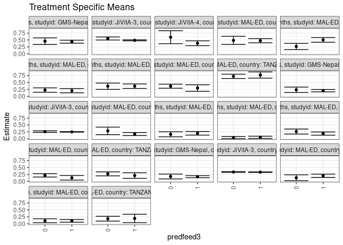

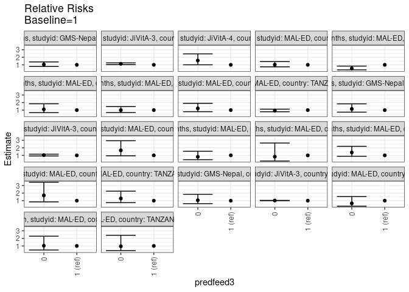

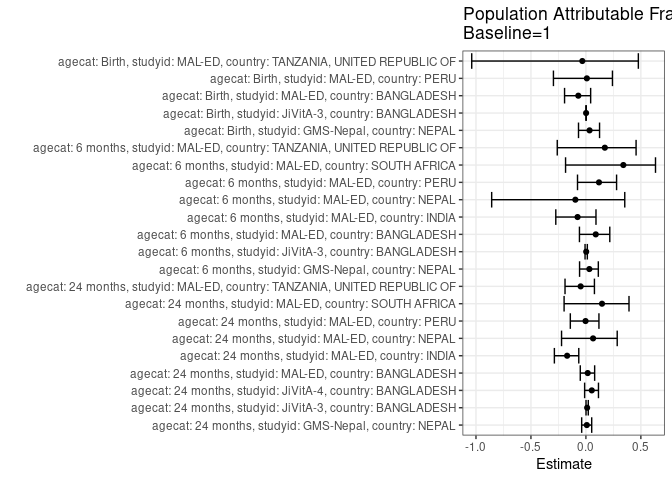

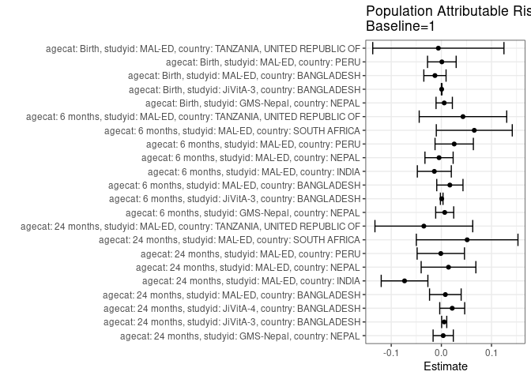

## Results Table

### Parameter: TSM

| agecat | studyid | country | intervention_level | baseline_level | estimate | ci_lower | ci_upper |
| --- | --- | --- | --- | --- | --- | --- | --- |
| Birth | GMS-Nepal | NEPAL | 1 | NA | 0.1646435 | 0.1272068 | 0.2020801 |
| Birth | GMS-Nepal | NEPAL | 0 | NA | 0.1731984 | 0.0853342 | 0.2610626 |
| Birth | JiVitA-3 | BANGLADESH | 1 | NA | 0.3294813 | 0.3203200 | 0.3386425 |
| Birth | JiVitA-3 | BANGLADESH | 0 | NA | 0.3356110 | 0.3245957 | 0.3466264 |
| Birth | MAL-ED | BANGLADESH | 1 | NA | 0.1988636 | 0.1397572 | 0.2579701 |
| Birth | MAL-ED | BANGLADESH | 0 | NA | 0.1282051 | 0.0230361 | 0.2333742 |
| Birth | MAL-ED | PERU | 1 | NA | 0.1066667 | 0.0571559 | 0.1561774 |
| Birth | MAL-ED | PERU | 0 | NA | 0.1095890 | 0.0377697 | 0.1814084 |
| Birth | MAL-ED | TANZANIA, UNITED REPUBLIC OF | 1 | NA | 0.1923077 | 0.0400700 | 0.3445454 |
| Birth | MAL-ED | TANZANIA, UNITED REPUBLIC OF | 0 | NA | 0.1842105 | 0.0966261 | 0.2717950 |
| 6 months | GMS-Nepal | NEPAL | 1 | NA | 0.2042471 | 0.1629721 | 0.2455221 |
| 6 months | GMS-Nepal | NEPAL | 0 | NA | 0.2359520 | 0.1383300 | 0.3335739 |
| 6 months | JiVitA-3 | BANGLADESH | 1 | NA | 0.2501752 | 0.2393853 | 0.2609651 |
| 6 months | JiVitA-3 | BANGLADESH | 0 | NA | 0.2588589 | 0.2300073 | 0.2877105 |
| 6 months | MAL-ED | BANGLADESH | 1 | NA | 0.1718970 | 0.1182678 | 0.2255262 |
| 6 months | MAL-ED | BANGLADESH | 0 | NA | 0.2861335 | 0.1501760 | 0.4220910 |
| 6 months | MAL-ED | INDIA | 1 | NA | 0.1997643 | 0.1348867 | 0.2646420 |
| 6 months | MAL-ED | INDIA | 0 | NA | 0.1625756 | 0.0719351 | 0.2532160 |
| 6 months | MAL-ED | NEPAL | 1 | NA | 0.0530973 | 0.0116634 | 0.0945313 |
| 6 months | MAL-ED | NEPAL | 0 | NA | 0.0438596 | 0.0061851 | 0.0815342 |
| 6 months | MAL-ED | PERU | 1 | NA | 0.1892196 | 0.1310489 | 0.2473903 |
| 6 months | MAL-ED | PERU | 0 | NA | 0.2625958 | 0.1724387 | 0.3527528 |
| 6 months | MAL-ED | SOUTH AFRICA | 1 | NA | 0.1269841 | 0.0445978 | 0.2093705 |
| 6 months | MAL-ED | SOUTH AFRICA | 0 | NA | 0.2154696 | 0.1554493 | 0.2754900 |
| 6 months | MAL-ED | TANZANIA, UNITED REPUBLIC OF | 1 | NA | 0.2069232 | 0.1059192 | 0.3079273 |
| 6 months | MAL-ED | TANZANIA, UNITED REPUBLIC OF | 0 | NA | 0.2679210 | 0.1961327 | 0.3397093 |
| 24 months | GMS-Nepal | NEPAL | 1 | NA | 0.4390449 | 0.3849665 | 0.4931233 |
| 24 months | GMS-Nepal | NEPAL | 0 | NA | 0.4560638 | 0.3369543 | 0.5751733 |
| 24 months | JiVitA-3 | BANGLADESH | 1 | NA | 0.4881710 | 0.4705918 | 0.5057502 |
| 24 months | JiVitA-3 | BANGLADESH | 0 | NA | 0.5536823 | 0.4982867 | 0.6090778 |
| 24 months | JiVitA-4 | BANGLADESH | 1 | NA | 0.3823529 | 0.2957347 | 0.4689712 |
| 24 months | JiVitA-4 | BANGLADESH | 0 | NA | 0.6000000 | 0.3670443 | 0.8329557 |
| 24 months | MAL-ED | BANGLADESH | 1 | NA | 0.4749960 | 0.3998024 | 0.5501896 |
| 24 months | MAL-ED | BANGLADESH | 0 | NA | 0.4860857 | 0.3391153 | 0.6330561 |
| 24 months | MAL-ED | INDIA | 1 | NA | 0.5041572 | 0.4204472 | 0.5878673 |
| 24 months | MAL-ED | INDIA | 0 | NA | 0.2661446 | 0.1534609 | 0.3788284 |
| 24 months | MAL-ED | NEPAL | 1 | NA | 0.2039213 | 0.1276783 | 0.2801643 |
| 24 months | MAL-ED | NEPAL | 0 | NA | 0.2261860 | 0.1475812 | 0.3047907 |
| 24 months | MAL-ED | PERU | 1 | NA | 0.3647785 | 0.2827992 | 0.4467578 |
| 24 months | MAL-ED | PERU | 0 | NA | 0.3642509 | 0.2501171 | 0.4783848 |
| 24 months | MAL-ED | SOUTH AFRICA | 1 | NA | 0.2994682 | 0.1815138 | 0.4174226 |
| 24 months | MAL-ED | SOUTH AFRICA | 0 | NA | 0.3666914 | 0.2943091 | 0.4390738 |
| 24 months | MAL-ED | TANZANIA, UNITED REPUBLIC OF | 1 | NA | 0.7686656 | 0.6568600 | 0.8804712 |
| 24 months | MAL-ED | TANZANIA, UNITED REPUBLIC OF | 0 | NA | 0.7218187 | 0.6449820 | 0.7986554 |

### Parameter: E(Y)

| agecat | studyid | country | intervention_level | baseline_level | estimate | ci_lower | ci_upper |
| --- | --- | --- | --- | --- | --- | --- | --- |
| Birth | GMS-Nepal | NEPAL | NA | NA | 0.1703057 | 0.1358418 | 0.2047695 |
| Birth | JiVitA-3 | BANGLADESH | NA | NA | 0.3300693 | 0.3209240 | 0.3392146 |
| Birth | MAL-ED | BANGLADESH | NA | NA | 0.1860465 | 0.1339088 | 0.2381842 |
| Birth | MAL-ED | PERU | NA | NA | 0.1076233 | 0.0668572 | 0.1483894 |
| Birth | MAL-ED | TANZANIA, UNITED REPUBLIC OF | NA | NA | 0.1862745 | 0.1103463 | 0.2622027 |
| 6 months | GMS-Nepal | NEPAL | NA | NA | 0.2108844 | 0.1727677 | 0.2490010 |
| 6 months | JiVitA-3 | BANGLADESH | NA | NA | 0.2508576 | 0.2404565 | 0.2612588 |
| 6 months | MAL-ED | BANGLADESH | NA | NA | 0.1888412 | 0.1384789 | 0.2392035 |
| 6 months | MAL-ED | INDIA | NA | NA | 0.1857143 | 0.1329930 | 0.2384356 |
| 6 months | MAL-ED | NEPAL | NA | NA | 0.0484581 | 0.0204625 | 0.0764538 |
| 6 months | MAL-ED | PERU | NA | NA | 0.2148148 | 0.1657364 | 0.2638932 |
| 6 months | MAL-ED | SOUTH AFRICA | NA | NA | 0.1926230 | 0.1430395 | 0.2422064 |
| 6 months | MAL-ED | TANZANIA, UNITED REPUBLIC OF | NA | NA | 0.2500000 | 0.1915738 | 0.3084262 |
| 24 months | GMS-Nepal | NEPAL | NA | NA | 0.4427083 | 0.3929634 | 0.4924533 |
| 24 months | JiVitA-3 | BANGLADESH | NA | NA | 0.4938170 | 0.4765272 | 0.5111067 |
| 24 months | JiVitA-4 | BANGLADESH | NA | NA | 0.4039735 | 0.3218653 | 0.4860818 |
| 24 months | MAL-ED | BANGLADESH | NA | NA | 0.4829268 | 0.4143544 | 0.5514993 |
| 24 months | MAL-ED | INDIA | NA | NA | 0.4306931 | 0.3622377 | 0.4991484 |
| 24 months | MAL-ED | NEPAL | NA | NA | 0.2181818 | 0.1634817 | 0.2728819 |
| 24 months | MAL-ED | PERU | NA | NA | 0.3636364 | 0.2964623 | 0.4308104 |
| 24 months | MAL-ED | SOUTH AFRICA | NA | NA | 0.3508772 | 0.2887937 | 0.4129607 |
| 24 months | MAL-ED | TANZANIA, UNITED REPUBLIC OF | NA | NA | 0.7336957 | 0.6696530 | 0.7977384 |

### Parameter: RR

| agecat | studyid | country | intervention_level | baseline_level | estimate | ci_lower | ci_upper |
| --- | --- | --- | --- | --- | --- | --- | --- |
| Birth | GMS-Nepal | NEPAL | 1 | 1 | 1.0000000 | 1.0000000 | 1.0000000 |
| Birth | GMS-Nepal | NEPAL | 0 | 1 | 1.0519602 | 0.6036786 | 1.8331281 |
| Birth | JiVitA-3 | BANGLADESH | 1 | 1 | 1.0000000 | 1.0000000 | 1.0000000 |
| Birth | JiVitA-3 | BANGLADESH | 0 | 1 | 1.0186042 | 0.9987273 | 1.0388766 |
| Birth | MAL-ED | BANGLADESH | 1 | 1 | 1.0000000 | 1.0000000 | 1.0000000 |
| Birth | MAL-ED | BANGLADESH | 0 | 1 | 0.6446886 | 0.2694179 | 1.5426722 |
| Birth | MAL-ED | PERU | 1 | 1 | 1.0000000 | 1.0000000 | 1.0000000 |
| Birth | MAL-ED | PERU | 0 | 1 | 1.0273973 | 0.4602209 | 2.2935618 |
| Birth | MAL-ED | TANZANIA, UNITED REPUBLIC OF | 1 | 1 | 1.0000000 | 1.0000000 | 1.0000000 |
| Birth | MAL-ED | TANZANIA, UNITED REPUBLIC OF | 0 | 1 | 0.9578947 | 0.3804270 | 2.4119274 |
| 6 months | GMS-Nepal | NEPAL | 1 | 1 | 1.0000000 | 1.0000000 | 1.0000000 |
| 6 months | GMS-Nepal | NEPAL | 0 | 1 | 1.1552280 | 0.7289806 | 1.8307097 |
| 6 months | JiVitA-3 | BANGLADESH | 1 | 1 | 1.0000000 | 1.0000000 | 1.0000000 |
| 6 months | JiVitA-3 | BANGLADESH | 0 | 1 | 1.0347106 | 0.9218644 | 1.1613703 |
| 6 months | MAL-ED | BANGLADESH | 1 | 1 | 1.0000000 | 1.0000000 | 1.0000000 |
| 6 months | MAL-ED | BANGLADESH | 0 | 1 | 1.6645640 | 0.9431290 | 2.9378517 |
| 6 months | MAL-ED | INDIA | 1 | 1 | 1.0000000 | 1.0000000 | 1.0000000 |
| 6 months | MAL-ED | INDIA | 0 | 1 | 0.8138370 | 0.4265181 | 1.5528779 |
| 6 months | MAL-ED | NEPAL | 1 | 1 | 1.0000000 | 1.0000000 | 1.0000000 |
| 6 months | MAL-ED | NEPAL | 0 | 1 | 0.8260234 | 0.2588158 | 2.6362948 |
| 6 months | MAL-ED | PERU | 1 | 1 | 1.0000000 | 1.0000000 | 1.0000000 |
| 6 months | MAL-ED | PERU | 0 | 1 | 1.3877830 | 0.8758176 | 2.1990214 |
| 6 months | MAL-ED | SOUTH AFRICA | 1 | 1 | 1.0000000 | 1.0000000 | 1.0000000 |
| 6 months | MAL-ED | SOUTH AFRICA | 0 | 1 | 1.6968232 | 0.8375239 | 3.4377634 |
| 6 months | MAL-ED | TANZANIA, UNITED REPUBLIC OF | 1 | 1 | 1.0000000 | 1.0000000 | 1.0000000 |
| 6 months | MAL-ED | TANZANIA, UNITED REPUBLIC OF | 0 | 1 | 1.2947846 | 0.7422937 | 2.2584958 |
| 24 months | GMS-Nepal | NEPAL | 1 | 1 | 1.0000000 | 1.0000000 | 1.0000000 |
| 24 months | GMS-Nepal | NEPAL | 0 | 1 | 1.0387634 | 0.7823830 | 1.3791576 |
| 24 months | JiVitA-3 | BANGLADESH | 1 | 1 | 1.0000000 | 1.0000000 | 1.0000000 |
| 24 months | JiVitA-3 | BANGLADESH | 0 | 1 | 1.1341973 | 1.0231778 | 1.2572630 |
| 24 months | JiVitA-4 | BANGLADESH | 1 | 1 | 1.0000000 | 1.0000000 | 1.0000000 |
| 24 months | JiVitA-4 | BANGLADESH | 0 | 1 | 1.5692308 | 1.0057767 | 2.4483420 |
| 24 months | MAL-ED | BANGLADESH | 1 | 1 | 1.0000000 | 1.0000000 | 1.0000000 |
| 24 months | MAL-ED | BANGLADESH | 0 | 1 | 1.0233469 | 0.7335915 | 1.4275505 |
| 24 months | MAL-ED | INDIA | 1 | 1 | 1.0000000 | 1.0000000 | 1.0000000 |
| 24 months | MAL-ED | INDIA | 0 | 1 | 0.5279001 | 0.3343437 | 0.8335092 |
| 24 months | MAL-ED | NEPAL | 1 | 1 | 1.0000000 | 1.0000000 | 1.0000000 |
| 24 months | MAL-ED | NEPAL | 0 | 1 | 1.1091826 | 0.6679370 | 1.8419194 |
| 24 months | MAL-ED | PERU | 1 | 1 | 1.0000000 | 1.0000000 | 1.0000000 |
| 24 months | MAL-ED | PERU | 0 | 1 | 0.9985537 | 0.6820166 | 1.4620017 |
| 24 months | MAL-ED | SOUTH AFRICA | 1 | 1 | 1.0000000 | 1.0000000 | 1.0000000 |
| 24 months | MAL-ED | SOUTH AFRICA | 0 | 1 | 1.2244752 | 0.7909046 | 1.8957276 |
| 24 months | MAL-ED | TANZANIA, UNITED REPUBLIC OF | 1 | 1 | 1.0000000 | 1.0000000 | 1.0000000 |
| 24 months | MAL-ED | TANZANIA, UNITED REPUBLIC OF | 0 | 1 | 0.9390543 | 0.7830818 | 1.1260930 |

### Parameter: PAR

| agecat | studyid | country | intervention_level | baseline_level | estimate | ci_lower | ci_upper |
| --- | --- | --- | --- | --- | --- | --- | --- |
| Birth | GMS-Nepal | NEPAL | 1 | NA | 0.0056622 | -0.0106259 | 0.0219503 |
| Birth | JiVitA-3 | BANGLADESH | 1 | NA | 0.0005880 | -0.0000026 | 0.0011786 |
| Birth | MAL-ED | BANGLADESH | 1 | NA | -0.0128171 | -0.0350027 | 0.0093685 |
| Birth | MAL-ED | PERU | 1 | NA | 0.0009567 | -0.0275995 | 0.0295128 |
| Birth | MAL-ED | TANZANIA, UNITED REPUBLIC OF | 1 | NA | -0.0060332 | -0.1368996 | 0.1248333 |
| 6 months | GMS-Nepal | NEPAL | 1 | NA | 0.0066372 | -0.0113494 | 0.0246239 |
| 6 months | JiVitA-3 | BANGLADESH | 1 | NA | 0.0006824 | -0.0019266 | 0.0032915 |
| 6 months | MAL-ED | BANGLADESH | 1 | NA | 0.0169442 | -0.0092179 | 0.0431064 |
| 6 months | MAL-ED | INDIA | 1 | NA | -0.0140500 | -0.0479168 | 0.0198168 |
| 6 months | MAL-ED | NEPAL | 1 | NA | -0.0046392 | -0.0327696 | 0.0234912 |
| 6 months | MAL-ED | PERU | 1 | NA | 0.0255952 | -0.0126375 | 0.0638279 |
| 6 months | MAL-ED | SOUTH AFRICA | 1 | NA | 0.0656388 | -0.0101306 | 0.1414083 |
| 6 months | MAL-ED | TANZANIA, UNITED REPUBLIC OF | 1 | NA | 0.0430768 | -0.0442177 | 0.1303712 |
| 24 months | GMS-Nepal | NEPAL | 1 | NA | 0.0036634 | -0.0164997 | 0.0238266 |
| 24 months | JiVitA-3 | BANGLADESH | 1 | NA | 0.0056460 | 0.0005534 | 0.0107385 |
| 24 months | JiVitA-4 | BANGLADESH | 1 | NA | 0.0216206 | -0.0032699 | 0.0465111 |
| 24 months | MAL-ED | BANGLADESH | 1 | NA | 0.0079308 | -0.0236074 | 0.0394690 |
| 24 months | MAL-ED | INDIA | 1 | NA | -0.0734641 | -0.1200171 | -0.0269112 |
| 24 months | MAL-ED | NEPAL | 1 | NA | 0.0142605 | -0.0403089 | 0.0688299 |
| 24 months | MAL-ED | PERU | 1 | NA | -0.0011421 | -0.0483530 | 0.0460687 |
| 24 months | MAL-ED | SOUTH AFRICA | 1 | NA | 0.0514090 | -0.0499725 | 0.1527905 |
| 24 months | MAL-ED | TANZANIA, UNITED REPUBLIC OF | 1 | NA | -0.0349699 | -0.1325193 | 0.0625795 |

### Parameter: PAF

| agecat | studyid | country | intervention_level | baseline_level | estimate | ci_lower | ci_upper |
| --- | --- | --- | --- | --- | --- | --- | --- |
| Birth | GMS-Nepal | NEPAL | 1 | NA | 0.0332474 | -0.0672038 | 0.1242435 |
| Birth | JiVitA-3 | BANGLADESH | 1 | NA | 0.0017815 | -0.0000098 | 0.0035696 |
| Birth | MAL-ED | BANGLADESH | 1 | NA | -0.0688920 | -0.1941495 | 0.0432269 |
| Birth | MAL-ED | PERU | 1 | NA | 0.0088889 | -0.2953346 | 0.2416622 |
| Birth | MAL-ED | TANZANIA, UNITED REPUBLIC OF | 1 | NA | -0.0323887 | -1.0387102 | 0.4772056 |
| 6 months | GMS-Nepal | NEPAL | 1 | NA | 0.0314734 | -0.0575640 | 0.1130146 |
| 6 months | JiVitA-3 | BANGLADESH | 1 | NA | 0.0027205 | -0.0077382 | 0.0130706 |
| 6 months | MAL-ED | BANGLADESH | 1 | NA | 0.0897274 | -0.0586689 | 0.2173226 |
| 6 months | MAL-ED | INDIA | 1 | NA | -0.0756540 | -0.2738677 | 0.0917177 |
| 6 months | MAL-ED | NEPAL | 1 | NA | -0.0957361 | -0.8572107 | 0.3535264 |
| 6 months | MAL-ED | PERU | 1 | NA | 0.1191501 | -0.0763075 | 0.2791126 |
| 6 months | MAL-ED | SOUTH AFRICA | 1 | NA | 0.3407633 | -0.1850142 | 0.6332592 |
| 6 months | MAL-ED | TANZANIA, UNITED REPUBLIC OF | 1 | NA | 0.1723071 | -0.2606037 | 0.4565496 |
| 24 months | GMS-Nepal | NEPAL | 1 | NA | 0.0082751 | -0.0383630 | 0.0528184 |
| 24 months | JiVitA-3 | BANGLADESH | 1 | NA | 0.0114333 | 0.0010954 | 0.0216643 |
| 24 months | JiVitA-4 | BANGLADESH | 1 | NA | 0.0535198 | -0.0115565 | 0.1144095 |
| 24 months | MAL-ED | BANGLADESH | 1 | NA | 0.0164224 | -0.0511206 | 0.0796253 |
| 24 months | MAL-ED | INDIA | 1 | NA | -0.1705719 | -0.2867844 | -0.0648549 |
| 24 months | MAL-ED | NEPAL | 1 | NA | 0.0653606 | -0.2215485 | 0.2848825 |
| 24 months | MAL-ED | PERU | 1 | NA | -0.0031409 | -0.1417503 | 0.1186412 |
| 24 months | MAL-ED | SOUTH AFRICA | 1 | NA | 0.1465156 | -0.1983466 | 0.3921327 |
| 24 months | MAL-ED | TANZANIA, UNITED REPUBLIC OF | 1 | NA | -0.0476627 | -0.1899194 | 0.0775870 |